# Entry and Exit

Ernesto Carrella

December 14, 2015

## Varying the number of boats

Until now the number of fishers in a simulation was set at the start and remained fixed through the whole run.  
Here I let fishers in and out of the simulation to show its effects on biomass. There is still no “endogenous” way for people to enter and exit the fishery (no licensing, no profit imitation and so on ) but those will be easy to code now that the technicalities of adding and removing agents is in.

So usual setup, same logistic-boxes world as always. Run the simulation for 23 years. For the first 3, the number of fishers is set to 50. Then for the next 10 years 2 fishers enter the market every month. For the final 10 years, 2 fishers leave the market every month.

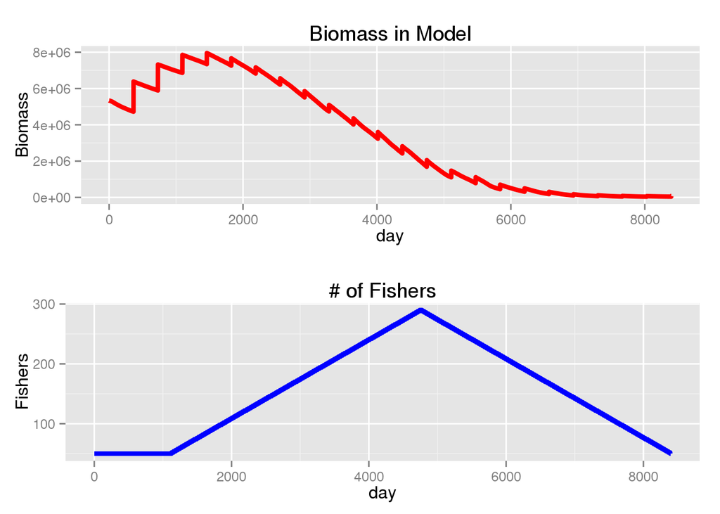

The first years the biomass increases (the large spikes upward are spawning days) implying that 50 fishers is a sustainable number of appropriators. However as more fishers enter the market the biomass starts declining. More importantly by the time the new entrants are removed the biomass is almost completely consumed and will not recover even when the fishers left are back to previously sustainable numbers.

All very obvious stuff but now it’s obvious stuff the model can do.